# Worked Example: D-Rex

Johan Larsson

Behnaz Pirzamanbein

Jonas Wallin

# 1 Probing an Unknown Dataset

Let’s say that we have data from an unknown source, containing two variables, `x` and `y`. The data has been uploaded to the course website, and you can download and read it into your workspace with the following command.

```r
library(tidyverse)

xy <- read_csv(
  "https://raw.githubusercontent.com/stat-lu/dataviz/main/data/xy.csv"
)
```

## 1.1 Box Plot

Let’s try to explore the univariate distributions of these two variables. We begin with a box plot.

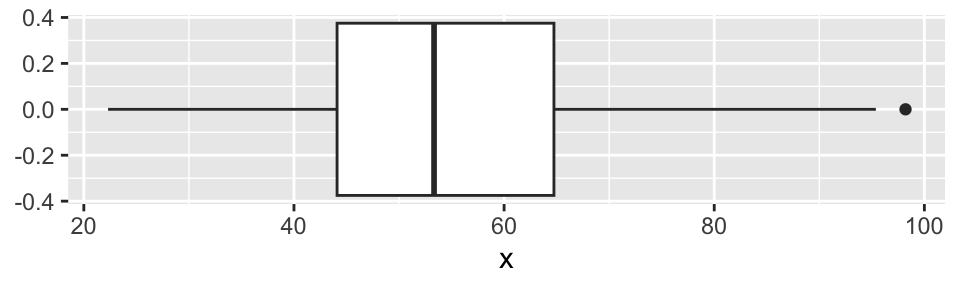

Figure 1: A boxplot of the x variable

```r
ggplot(xy, aes(x)) +
  geom_boxplot()
```

As you see, our call to ggplot2 is quite simple. We use `ggplot()` with the data as the first argument and a call to `aes()` for our aesthetics specification as our second argument. The call to `aes()` is actually optional and you can provide your mappings directly within the layers (geom functions) if you prefer.

The box plot shows a median around 53, a somewhat longer whisker to the right, and a single observation flagged as an outlier near 100. Box plots summarize location and spread using quantiles, so distributions with very different shapes can produce the same box plot. To explore whether this distribution has one peak or several, let’s look at a dot plot.

## 1.2 Dot Plot

When studying a distribution, it is usually better to start off with a plot that does less abstraction, such as a simple dot plot. In a dot plot, each observation is indicated by a dot.

When constructing the dot plot, the values that are used are cut in intervals (much like a histogram), and observations that fall within a given interval are stacked on top of one another. The maximum width of these intervals is decided by the `binwidth`, which by default is 1/30 times the range of the data. The exact behavior then depends on the setting of the `method` argument, which by default is `"dotdensity"`, which uses an algorithm from a paper by Wilkinson[^1]. Here, we try to use the `"histodot"` method instead, which works exactly like a histogram. We set the `binwidth` to 3.

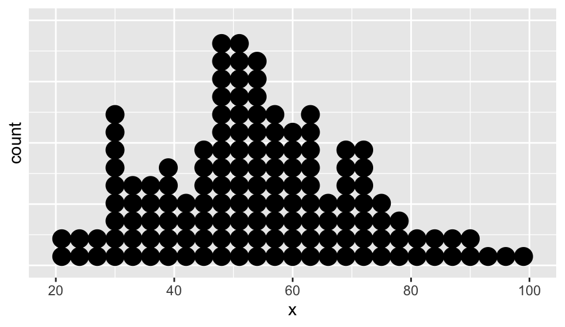

Figure 2: A dotplot of the x variable

```r
ggplot(xy, aes(x)) +
  geom_dotplot(method = "histodot", binwidth = 3) +
  guides(y = "none") # do you remember why we did this?
```

Try changing the `method` argument to the default, and then try playing a bit with the `binwidth` settings.

It’s hard to summarize this distribution in a few words, but it does not quite seem to be uni-modal. There is also a slight indication that the values may be biased towards certain values here, which for instance is a common problem in questionnaires, where many will “round off” their answers to a whole number when they are uncertain about the answer.

## 1.3 Histogram

Perhaps this is the case here, so let’s use a *histogram* instead. Just as with the dot plot, we need to specify the `binwidth` (or number of bins, `bins`) here. Given the number of observations here, and the dot plot we previously plotted, a bin width of five might be appropriate to remove the effect of possible round-off bias and elucidate the shape of the distribution better.

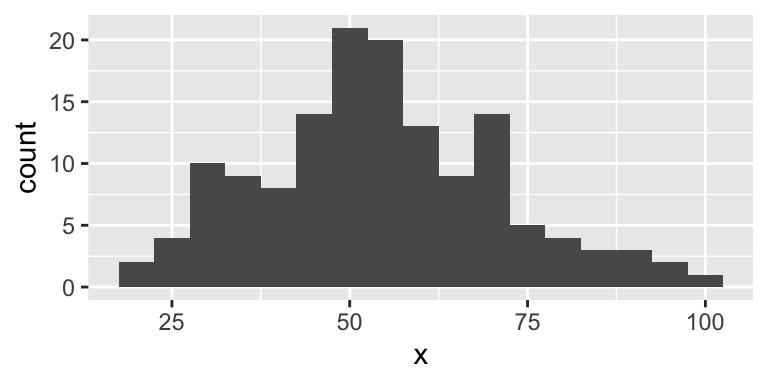

Figure 3: A histogram of the x variable

```r
ggplot(xy, aes(x)) +
  geom_histogram(binwidth = 5)
```

Play around a little bit with the various settings of `bins` and/or `binwidth` to see how large the effects of these parameters can be.

## 1.4 Density Plot

We could also try a density plot here. Density plots are best when you know that your data is measured on a continuous scale and you can make strong assumptions about the distributions of your variables. This is because the choice of parameters for the density kernel has a large effect on the result.

Here, we try a few different choices to highlight this.

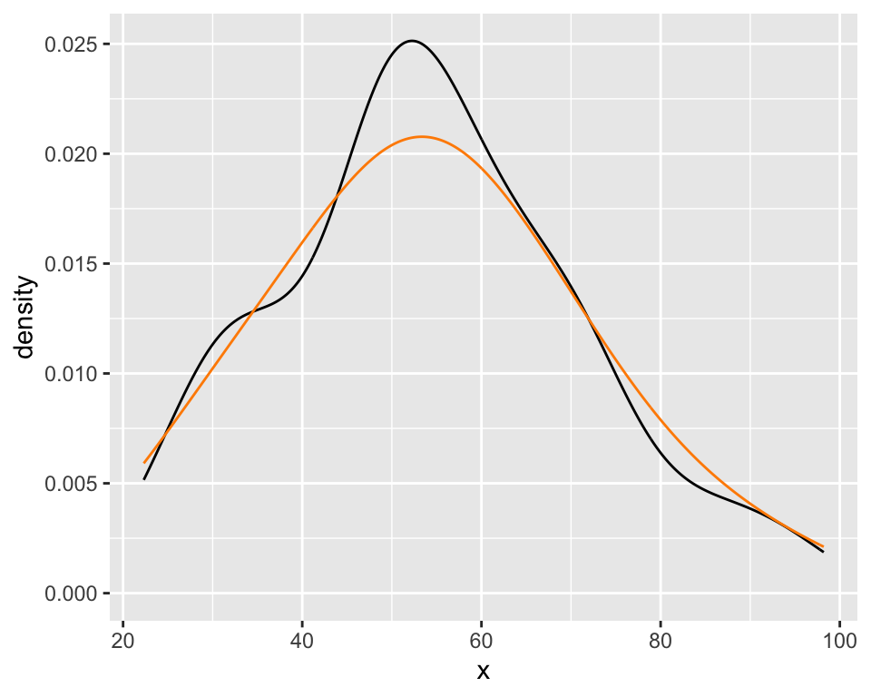

Figure 4: Density plots with various density estimate choices

```r
ggplot(xy, aes(x)) +
  geom_density() + # kernel = "gaussian", the default
  geom_density(col = "dark orange", bw = 10)
```

Try adding another density estimate, this time with a *rectangular* kernel.

The default density layer uses Silverman’s rule-of-thumb (see `?bw.nrd0`) for choosing band width but there are other choices that are probably better, such as `bw = "SJ"`. Try this out too.

## 1.5 Violin Plot

A violin plot displays a kernel density estimate mirrored around a centreline. In the horizontal violin below, the shape is thicker at `x` values where the estimated density is higher. As with a density plot, its shape depends on the bandwidth.

We use `y = 1` to position a single violin. This constant does not refer to the `y` variable in the dataset; the plot shows the distribution of `x` only. We therefore hide the vertical axis. We save the plot as `p3` to combine it with other plots below.

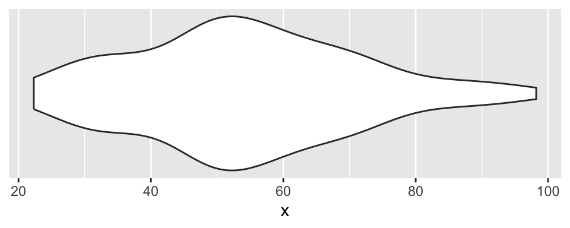

Figure 5: A horizontal violin plot of the x variable

```r
p3 <- ggplot(xy, aes(x, y = 1)) +
  geom_violin() +
  scale_y_continuous(NULL, breaks = NULL)

p3
```

### 1.5.1 Adding Observations and a Box Plot

We can make the violin plot more informative by combining it with other layers. The violin shows the smoothed distribution, the narrow box plot shows the quartiles and median, and the points show the individual observations. We also add a white circle to make the median easier to see.

The points are *jittered*: we add small random vertical offsets to reduce overlap. Setting `width = 0` keeps their original `x` values unchanged, while `seed = 1` makes the offsets reproducible. We hide the box plot’s separate outlier dots with `outlier.shape = NA`, since these observations are already included in the point layer.

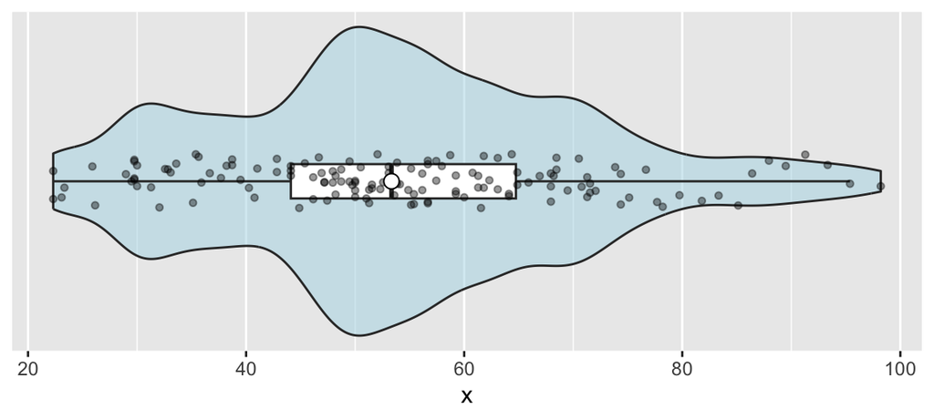

Figure 6: A violin plot with observations, a box plot, and a median marker

```r
ggplot(xy, aes(x, y = 1)) +
  geom_violin(fill = "lightblue", alpha = 0.5,adjust = 0.5) +
  geom_boxplot(width = 0.1, outlier.shape = NA, fill = "white") +
  geom_point(
    position = position_jitter(width = 0, height = 0.08, seed = 1),
    alpha = 0.4,
    size = 1.2
  ) +
  annotate("point", x = median(xy$x), y = 1, shape = 21,
           size = 3, fill = "white") +
  scale_y_continuous(NULL, breaks = NULL)
```

## 1.6 Compactly Displaying Several Univariate Distributions

It can sometimes be useful to display several plots of univariate distributions in a compact design.

### 1.6.1 Overlaying a Histogram and Density Curve

We can display a histogram and a kernel density estimate in the same plot. Both layers below use `x`, allowing us to compare a binned and a smoothed view of the same distribution.

To put them on the same vertical scale, we use `aes(y = after_stat(density))` in the histogram layer. The area of each bar then represents the fraction of observations in that bin, and the total area of the bars is one. This makes the histogram comparable to the density curve.

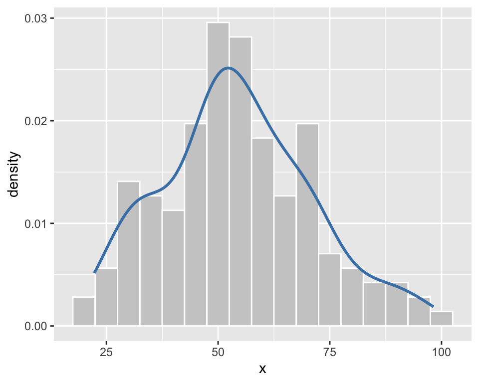

Figure 7: A histogram and kernel density estimate of x in the same plot

```r
ggplot(xy, aes(x)) +
  geom_histogram(
    aes(y = after_stat(density)),
    binwidth = 5,
    fill = "grey80",
    colour = "white"
  ) +
  geom_density(colour = "steelblue", linewidth = 1)
```

### 1.6.2 Arranging Separate Plots with Patchwork

To arrange separate plots, we can use the patchwork package, which can *patch* together plots that we have created separately.

Let’s install the package first.

```r
install.packages("patchwork")
```

**patchwork** is simple and intuitive yet powerful. Most of its functionality can be obtained simply by using binary operators (such as `+`) to patch plots together.

- `+` combines plots in an automatically chosen grid,
- `|` places plots side by side, and
- `/` stacks plots vertically.

In the following plot, we patch a histogram and density plot together.

[figure not shown]

Figure 8: Density plot of x and histogram of y

```r
library(patchwork)

p1 <- ggplot(xy, aes(x)) +
  geom_density(bw = "SJ")

p2 <- ggplot(xy, aes(y)) +
  geom_histogram(bins = 12)

p1 | p2
```

Next, we try to stack them vertically.

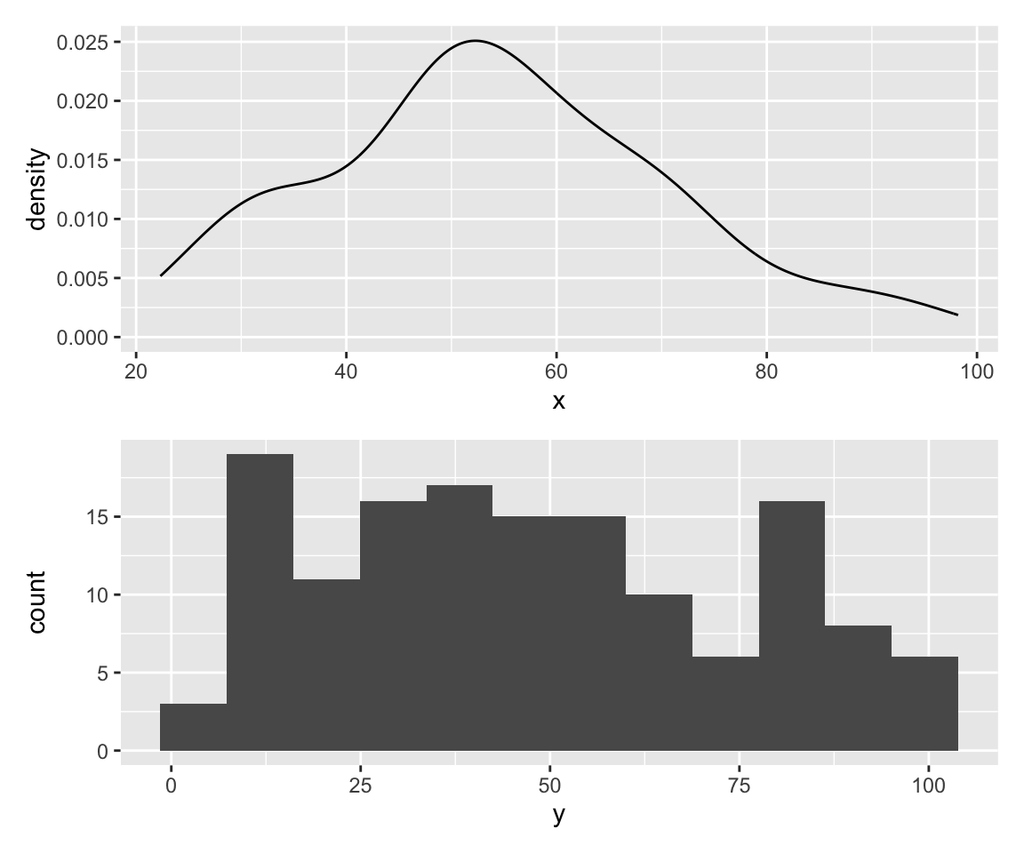

Figure 9: Density plot of x and histogram of y.

```r
p1 / p2
```

We can also include our violin plot in a more complicated layout and add labels to the plots.

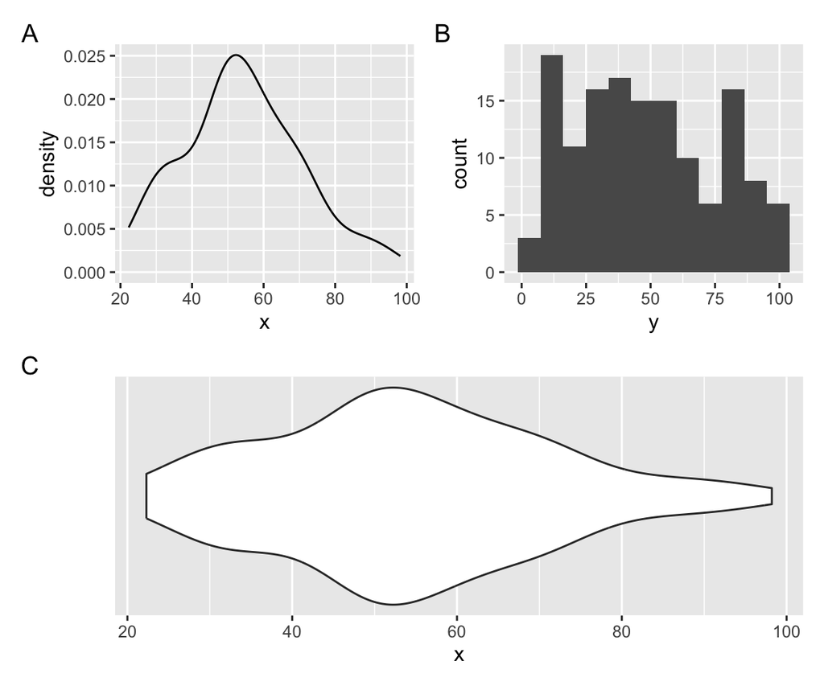

```r
pw <- (p1 | p2) / p3

pw + plot_annotation(tag_levels = "A")
```

Simple, right? Play around with patchwork and it’s various options.

It’s particularly useful to know that if you have a shared legend, such as a color legend, between the plots you’re combining, patchwork will automatically merge these guides into one.

For more examples, check out [documentation](https://patchwork.data-imaginist.com/index.html).

# 2 Rawr!

We’ve now plotted several types of plots of the distributions of this dataset and might well feel comfortable about making a few conclusions about the data. However, stopping here would be a severe mistake. The reason is that we’ve overlooked plotting the *joint* distribution of these variables, which can be easily done using a scatter plot. We will explore this in much more detail in the next part of the course.

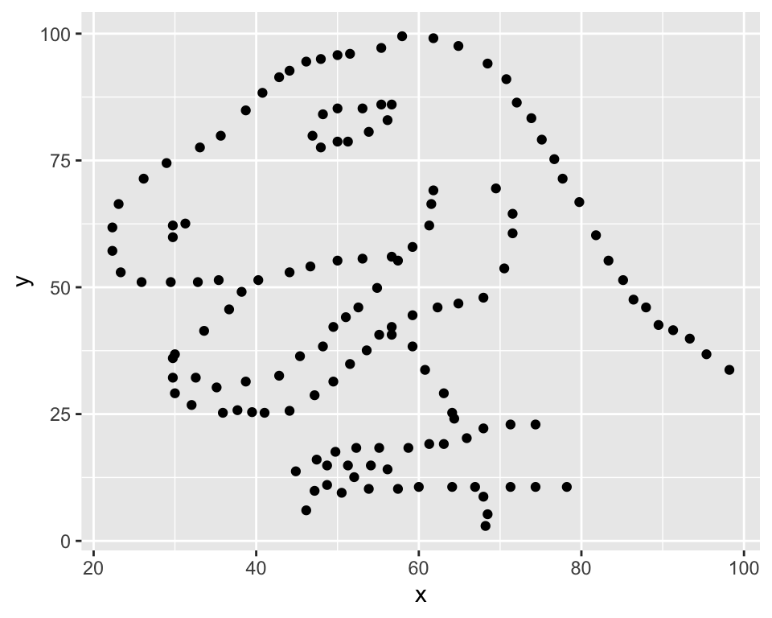

Figure 10: The terrifying Datasaurus Rex

```r
ggplot(xy, aes(x, y)) +
  geom_point()
```

Despite the clear pattern in the scatter plot, the usual summary statistics give little indication of its shape. Let’s calculate the means, standard deviations, and Pearson’s correlation.

```r
summarise(
  xy,
  mean_x = mean(x),
  mean_y = mean(y),
  sd_x = sd(x),
  sd_y = sd(y),
  correlation = cor(x, y)
)
```

```
## # A tibble: 1 × 5
##   mean_x mean_y  sd_x  sd_y correlation
##    <dbl>  <dbl> <dbl> <dbl>       <dbl>
## 1   54.3   47.8  16.8  26.9     -0.0645
```

The correlation is approximately -0.0645, which is close to zero. Pearson’s correlation measures linear association, so a value near zero can coexist with clear structure in a scatter plot, as we see here.

What is the take-home message here? Well, it’s twofold:

1. When you visualize distributions of several variables one by one, you are projecting these distributions from a multivariate space into a univariate space. In doing so, you effectively ignore all the ways in which these variables are related to each another. To be fair, visualizing many variables at once isn’t always easy (or even possible). However, in this case, we would have been far better off considering a scatter plot from the start.
2. Knowing your data is critical. You should never throw yourself into a dataset without at least some understanding of what the variables represent, and ideally, how they were collected. Make it a habit to familiarize yourself with the dataset *before* you start visualizing it. For most of the data we’ll tackle in this course, documentation is often available, which you can access by looking at the help file for the dataset.

# 3 Source Code

The source code for this document is available at https://github.com/stat-lu/dataviz/blob/main/worked-examples/drex.Rmd.

[^1]: Remember him? The author of the original grammar of graphics.